# 1 — Introduction

Machine Learning (MPA-MLR)

Tomáš Vičar

Department of Biomedical Engineering · FEEC, Brno University of Technology

2026

## Course outline — lectures and labs

**Lectures**

1. Introduction, optimization
2. Performance evaluation, preprocessing
3. Feature selection, dimensionality reduction
4. Vibecoding — how coding agents work
5. Linear models and kernels
6. Decision trees and ensembles
7. Artificial neural networks
8. Convolutional networks 1: basics
9. Convolutional networks 2: special blocks
10. Other networks: architectures, applications
11. Transformers
12. Generative models, wrap-up

**Computer labs** (Python)

1. Introduction, libraries, nearest neighbour
2. k-NN as an object, metrics, splitting
3. Feature selection
4. Linear, ridge and kernel regression
5. Coding agents and Git
6. SVM, decision trees, random forest
7. Neural network from scratch
8. PyTorch
9. Deep-learning showcase with an agent
10. Practical application on MetaCentrum
11. Transformers
12. Project

## Course evaluation

- Everything about the assessment — the semester tests, the project, the credit and the oral exam — is explained **in the first computer lab**.
- The rules are also on the course web: https://tomasvicar.github.io/MLR-public/organisation.html.

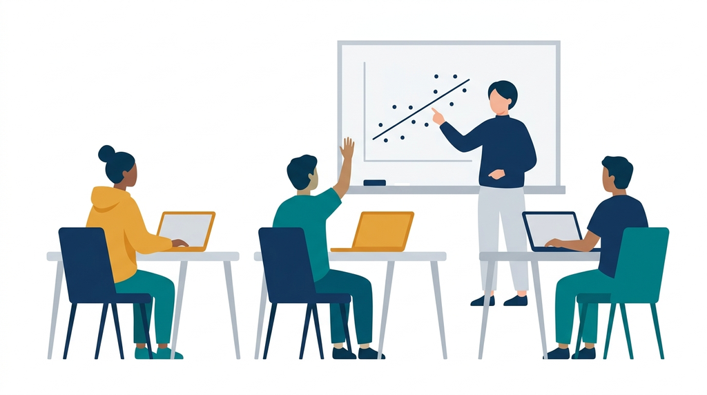

## How we code now

> Most new code in the industry is now written by AI agents and only checked by people. What does that mean for a machine-learning course?

## Who writes the code today

- The code is written by a **coding agent** (Claude Code, Codex, …). The human **specifies the task and checks the result**.
- A year ago: writing code with AI suggestions. Today: reviewing AI-written code. **It will keep changing this fast.**
- Our own research at the department works the same way.

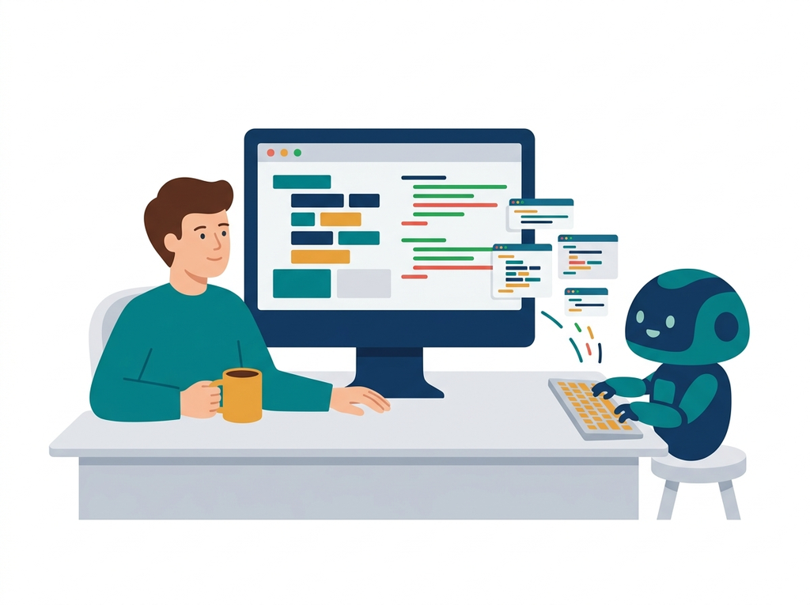

## What the companies report

[figure not shown]

- **Google:** 75 % of new code is AI-generated (25 % in 2024, 50 % in autumn 2025).
- **Anthropic:** more than 80 % of merged code is written by Claude; low single digits before February 2025.

Google: Alphabet Q1 2026 earnings call (Semafor, 24 April 2026). Anthropic: *When AI builds itself*, May 2026.

## What does that mean for this course?

- Nobody knows which skills will be needed in five years — **so it is hard to decide what to teach.**
- What will not go away: **understanding the methods.** It lets you tell an agent what to build and notice when a result cannot be right.
- Somebody has to tell *almost right* from *right*.

[figure not shown]

## So why do we still write Python by hand?

- **To understand the principle, not to ship it:** k-NN, forward selection, backpropagation — each written once, in NumPy.
- **More by hand:** a distance, a metric, one split of a tree — on paper first, then in code.
- **One lecture and one lab on vibecoding**, then agents in the later labs and the project.
- **Reading code you did not write:** find what is wrong with a pipeline — the main job once an agent writes it.

[figure not shown]

## Outline

1. **Definitions** — what is AI, ML, DL and how they relate
2. **Branches of Machine Learning** — supervised, unsupervised, reinforcement, self-supervised
3. **Optimization** — the language in which almost every ML method is written
4. *Appendix 1, after the quiz:* **Mathematical background** — notation, linear algebra, derivatives, probability *(self-study)*
5. *Appendix 2:* **Recap of the simplest algorithms** — k-NN, k-means, UPGMA *(self-study)*

## 1 · Definitions

> What exactly do we mean by artificial intelligence, machine learning and deep learning — and how do they fit into each other?

## Classical Programming vs. Machine Learning

**Classical Programming**

- Human provides **rules** + **data**, computer produces **answers**.
- Sorting, taxes, FIR filtering.

**Machine Learning**

- Human provides **data** + **answers**, computer learns the **rules** (model).
- Spam filter, image classification, LLMs.

[figure not shown]

## Artificial Intelligence vs. Machine Learning

**Artificial Intelligence (AI)**

- Systems that perform tasks requiring human intelligence: language, decisions, driving.
- **AI = umbrella term**.

**Machine Learning (ML)**

- Learning patterns from data: spam, recommenders, medical images.
- **ML = one way to achieve AI**.

[figure not shown]

## Machine Learning vs. Deep Learning

**Deep learning** = ML with *neural networks of many layers*: the features are learned **automatically**, at the price of big data and compute.

| Machine Learning | Deep Learning |
| --- | --- |
| Manual features | Automatic features |
| Small data OK | Needs big data |
| Traditional algorithms | Neural networks |

[figure not shown]

## Related fields: data science, computer vision, robotics

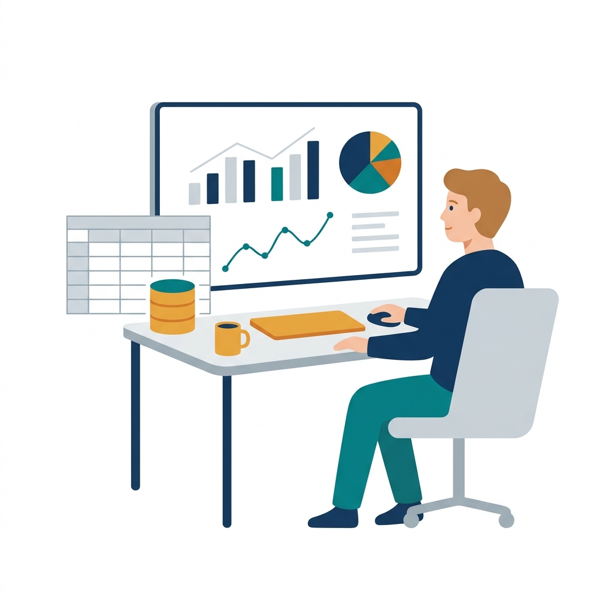

**Data science** — statistics + ML + computer science; **insight from data**. ML is one of its tools.

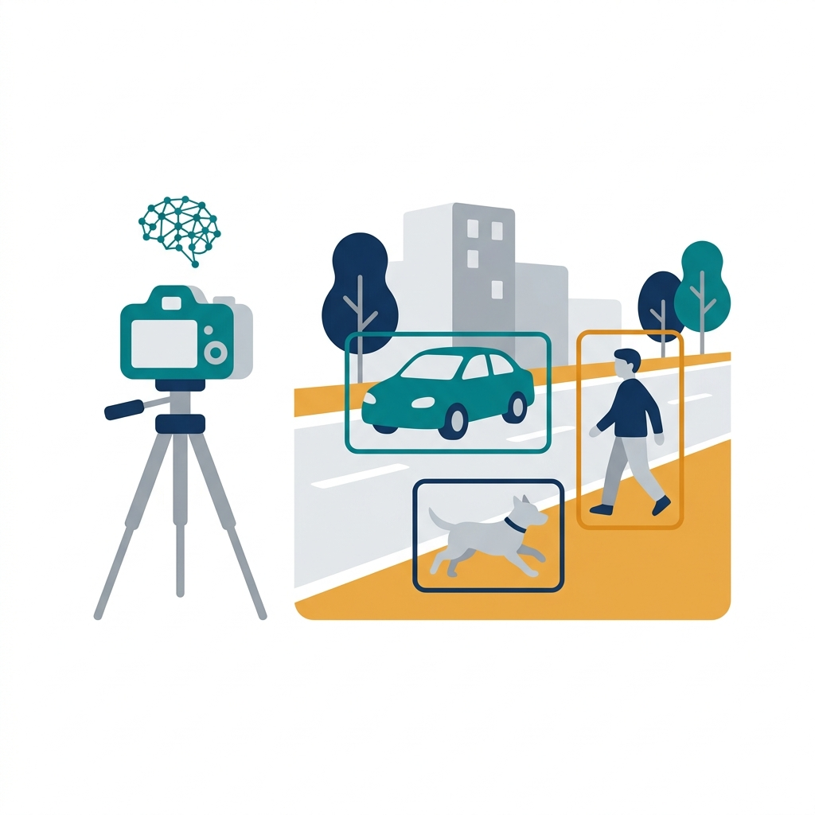

**Computer vision** — *information from images and video*: detection, segmentation, medical imaging. Today mostly deep learning.

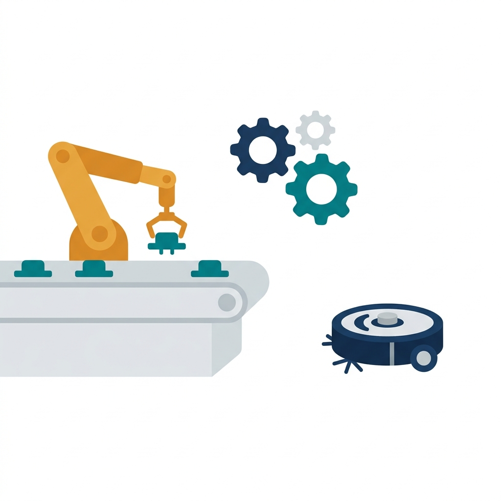

**Robotics** — *building and programming robots* for the real world; AI + vision + control + mechanics.

## The Turing test, narrow AI and AGI

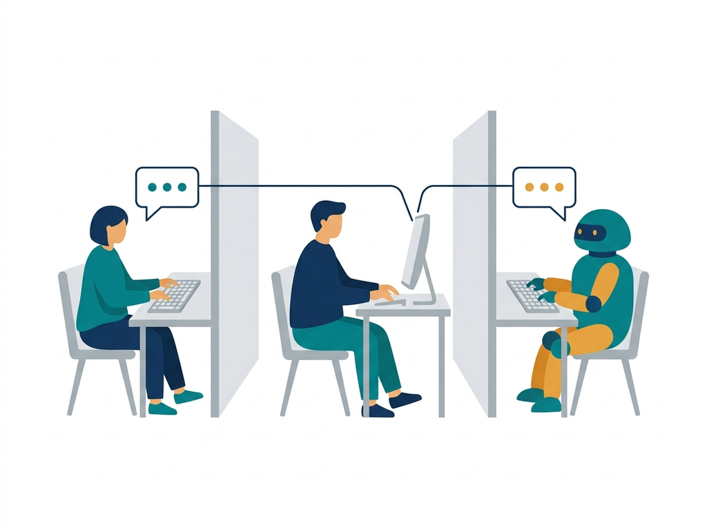

**The Turing test** (1950): if an evaluator cannot tell the machine’s replies from a human’s, the machine behaves intelligently. LLMs pass it — the test measures **behaviour, not understanding**.

**Narrow AI (weak AI)** — one system, *one task*: a spam filter, a recommender, an image classifier. **Everything in this course is narrow AI.**

**Artificial General Intelligence (AGI, strong AI)** — a hypothetical system that would *learn and apply knowledge across domains*, any intellectual task a human can do. Still a **theoretical concept**; LLMs come closest.

Do machines *think*, or only *simulate* thinking? An open question — this course does not need the answer.

## 2 · Branches of Machine Learning

> What kind of information do we give the algorithm — labels, nothing at all, or a reward?

## Branches of Machine Learning

[figure not shown]

## Supervised Learning

**Definition**

- Learning from *labelled data*: inputs $\mathbf x$ with known outputs $y$.
- Goal: a mapping $f:\mathbf x\mapsto y$ that **generalizes** to unseen data.
- Example: cat vs. dog.

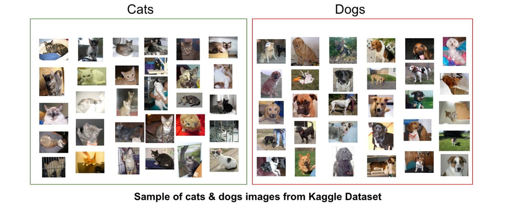

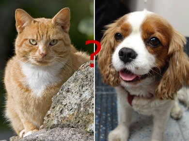

## Regression

- *Supervised* learning with a **continuous** target $y$.
- Fit $\hat y=f(\mathbf x)$ to minimize the error between $\hat y$ and $y$.
- Example: house prices, cholesterol level.

[figure not shown]

## Classification

- *Supervised* learning with a **discrete** target: one of several *classes*.
- Learn a decision function $\hat y=f(\mathbf x)$ that separates the classes.
- Example: **cat vs. dog**, **healthy vs. diseased**.

[figure not shown]

## Unsupervised Learning

**Definition**

- Learning from *unlabelled data*: only $\mathbf x$, no $y$.
- Goal: find **hidden structure** in the data.

**Three branches** (one slide each)

- **Clustering** — group similar samples.
- **Dimensionality reduction** — fewer features, same structure.
- **Generative models** — learn the distribution, draw new samples.

[figure not shown]

## Unsupervised Learning: Clustering

**What it is**

- Group the samples so that **similar ones end up together**.
- No labels — **nobody says how many groups** or what they mean.
- “Similar” = *close*: everything hangs on the distance.

**Typical uses**

- Customer segments, cell types.
- Grouping images or documents before annotation.

[figure not shown]

Two clustering algorithms, **k-means** and **UPGMA**, are recapitulated in Appendix 2 of this lecture.

## Unsupervised Learning: Dimensionality Reduction

**What it is**

- Replace many features by a few and keep the **structure**.
- Keep the directions with variation, drop those where the data barely change.

**Typical uses**

- **Visualisation** — 2 dimensions instead of 200.
- **Denoising**, **compression before a classifier**.

[figure not shown]

Feature selection, PCA, t-SNE and UMAP are the subject of the whole third lecture.

## Unsupervised Learning: Generative Models and LLMs

**What it is**

- The model learns the **distribution** of the data, not a label.
- It can then **draw new samples** — like the training set, but new.

**Large language models (LLMs)**

- Trained on huge text to **predict the next token**.
- The label is the next word itself — no annotation: **self-supervised**.
- Generating = predict, append, repeat (diffusion models: the same with pixels).

[figure not shown]

A chat model *answers* instead of *continuing* thanks to a second stage: **instruction tuning** and **RLHF** (reinforcement learning from human feedback). Transformers: the eleventh lecture; generative models: the twelfth.

## Reinforcement Learning

**Definition**

- An **agent** interacts with an *environment*: observes the **state**, takes an **action**, receives a **reward**.
- Goal: a policy that maximizes the cumulative reward.

**Examples:** robots in mazes, AlphaGo, Atari games.

**Not in this course** — a specific and rather complex field, a course of its own. It returns here only by name: RLHF.

[figure not shown]

## Self-Supervised Learning

**Definition**

- **Pseudo-labels** made from the data itself.
- A **pretext task** solved to learn a *representation* for later tasks.

**Examples of pretext tasks**

- Predict a masked word or missing pixels.
- Contrastive learning: **similar closer**, **dissimilar apart**.
- Next frame in a video, *next word in a sentence (LLMs)*.

[figure not shown]

## 3 · Optimization

> Almost every machine learning method boils down to minimizing something. Let us recall what that means.

## Mathematical Background for ML

Three questions, one minute each, on paper:

**Calculus**

Where is the minimum of $f(x)=3x^2+5x+1$, and how do you know it is one?

*Needed for:* derivatives, gradients, the chain rule — and **optimization**, which starts on the next slide.

*In ML:* training a network is gradient descent on the loss; backpropagation **is** the chain rule.

**Linear algebra**

$$\begin{pmatrix}1&2\\3&4\end{pmatrix}\begin{pmatrix}1\\-1\end{pmatrix}=\ ?$$

*Needed for:* vectors, matrices, eigenvalues.

*In ML:* a layer of a network is one matrix product $W\mathbf x$; PCA is the eigenvectors of the covariance.

**Probability and statistics**

What is the expected value of one roll of a fair die?

*Needed for:* random variables, expectation, variance, Bayes’ theorem.

*In ML:* a classifier outputs probabilities and its loss is a log-likelihood; Bayes says what a positive test means for a rare disease.

Answers in the recap quiz. If one took you more than a minute, revise it this week — **Appendix 1** after the recap quiz sums up all three. **Optimization** — the fourth area, and the language of every method here — is the rest of today (in depth: MPA-EAL).

## Optimization: intuition

- Change the inputs to get the **best possible output**: minimize a cost or maximize a reward.
- A **landscape**: look for the lowest valley.
- Constraints say which parts are **accessible**.
- Almost everything is optimization: a portfolio (max profit), a route (min time)…

[figure not shown]

## Optimization example: mixing hot and cold water

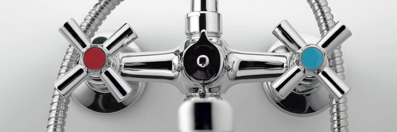

- **Inputs:** two handles — hot and cold.
- **Output:** how good the water feels.
- **Goal:** set the handles to the **best feeling**.

No formula, no graph — only a hand under the water. How do you find the best setting?

## Playground: find the most economical speed

[interactive chart not shown]

**Click** on a speed to measure the fuel consumption there. The curve is hidden — find the minimum with as few measurements as you can.

No measurements yet.

## Speed vs. fuel (1/3): probing an unknown curve

- Low speed: idling losses, short gearing.
- High speed: aerodynamic drag $\propto v^2$.
- Hence an **optimal speed** in between.
- The true curve is unknown — we can only **probe** it.

**One problem, three ways:** probing, closed form, gradient descent.

[figure not shown]

## Speed vs. fuel (2/3): the closed form

**Simple model:**

$$\mathrm{Fuel}(v)=\frac{A}{v}+Bv+C$$

(the rising term is kept linear in $v$ for simplicity)

**Optimum condition (derivative equal to zero):**

$$\frac{d}{dv}\mathrm{Fuel}(v)=0\ \Rightarrow\ -\frac{A}{v^2}+B=0$$

**Solution:**

$$v^\star=\sqrt{\tfrac{A}{B}}$$

Second derivative $\tfrac{2A}{v^3}>0$: a **unique minimum**. With $A=400$, $B=0.05$: $v^\star=\sqrt{8000}\approx89.4$ km/h, $\mathrm{Fuel}(v^\star)=2\sqrt{AB}+C\approx10.4$ L/100 km.

**A closed form is a luxury** — it needs the formula. Without it: the next slides.

[figure not shown]

## Gradient descent

**Intuition:** change the input; if the objective improves, keep going, otherwise turn around — as with the speed and the fuel.

The gradient points in the direction of the *steepest increase*; to minimize, we step **against** it.

The **gradient** $\nabla f(\mathbf x)$ is a vector of partial derivatives:

$$\nabla f(\mathbf x)=\Bigl(\frac{\partial f}{\partial x_1},\frac{\partial f}{\partial x_2},\dots,\frac{\partial f}{\partial x_n}\Bigr)$$

**Gradient descent update rule:**

$$\mathbf x^{(t+1)}=\mathbf x^{(t)}-\eta\,\nabla f(\mathbf x^{(t)})$$

$\eta>0$ is the **learning rate** (step size). This is how neural networks are trained.

[figure not shown]

## Speed vs. fuel (3/3): gradient descent step by step

One variable, so the gradient is just the derivative:

$$\mathrm{Fuel}'(v)=-\frac{A}{v^2}+B,\qquad v_{t+1}=v_t-\eta\,\mathrm{Fuel}'(v_t)$$

Start at $v_0=30$ km/h with $\eta=200$:

| $t$ | $v_t$ | $\mathrm{Fuel}'(v_t)$ | $v_{t+1}$ |
| --- | --- | --- | --- |
| 0 | 30.0 | $-400/900+0.05=-0.394$ | 108.9 |
| 1 | 108.9 | $+0.016$ | 105.6 |
| 2 | 105.6 | $+0.014$ | 102.8 |
| ⋮ |  |  |  |
| 30 | 89.5 | $\approx0$ |  |

Both learning rates converge to the closed-form optimum $v^\star=89.4$ — but a large $\eta$ overshoots the minimum in the first step, a small one creeps.

**Three ways, one problem:** probing is blind, the closed form needs the formula, gradient descent needs only the derivative — and that is how neural networks are trained.

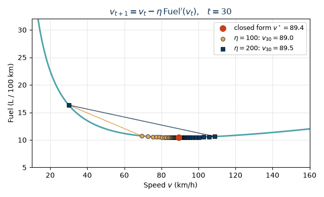

## Gradient descent: the step size decides everything

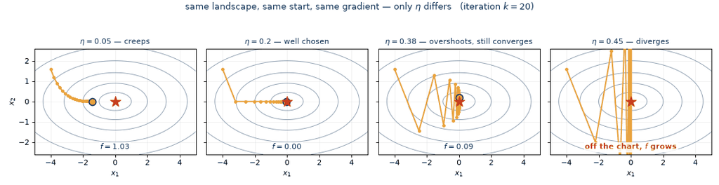

On $f(\mathbf x)=\tfrac12\bigl(x_1^2+5x_2^2\bigr)$ the update is $x_i\leftarrow(1-\eta q_i)\,x_i$, $q_1=1$, $q_2=5$: each step multiplies the error by $|1-\eta q_i|$. Convergence **exactly when**

$$|1-\eta q_i|<1\ \ \text{for all }i
\qquad\Longleftrightarrow\qquad
\eta<\frac{2}{L},$$

$L=\max_i q_i=5$ is the largest curvature — hence $\eta<0.4$ in the panels.

**When to stop?** Small gradient $\|\nabla f(\mathbf x)\|<\varepsilon$, small change of $f$ or $\mathbf x$, a cap on iterations; when training, the validation error (second lecture).

A small gradient only means a **stationary point** — a saddle or a plateau qualifies too. In a convex problem it is the global minimum.

## Mixing hot and cold water: a mathematical model

**Model** — flows $H,C$ (L/min), hot 60 °C, cold 10 °C:

$$T=\frac{60H+10C}{H+C},\qquad F=H+C$$

**Objective** and **feasible set**:

$$J=(T-38.5)^2+(F-12)^2,\qquad X=\{0\leq H\leq5,\ C\geq0\}$$

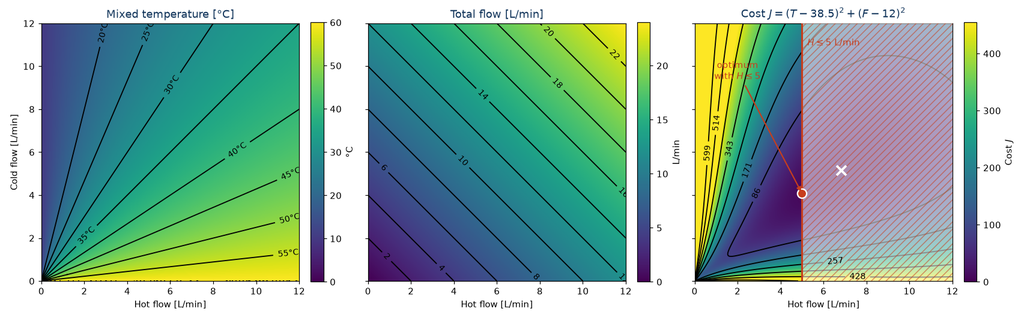

Without the limit: $H+C=12$, $\ \frac{60H+10C}{12}=38.5\ \Rightarrow\ H=6.84,\ C=5.16$ (the white cross). **Boiler limited to $H\leq5$** (hatched): the optimum moves to the boundary, $C=4.08$ — 37.5 °C, 9.1 L/min, $J=9.5$ instead of $0$.

## Definition of optimization

**Problem definition:**

$$\mathbf x^\star\in\arg\min_{\mathbf x\in X} f(\mathbf x)$$

**Canonical form:**

$$\begin{aligned}
\text{minimize}\quad & f(\mathbf x)\\
\text{subject to}\quad & g_i(\mathbf x)\leq 0,\quad i=1,\dots,m\\
& h_j(\mathbf x)=0,\quad j=1,\dots,p
\end{aligned}$$

$$X=\{\mathbf x\in\mathbb R^n:g_i(\mathbf x)\leq0,\ h_j(\mathbf x)=0\}$$

**Every problem has the same three parts:**

- **variables** $\mathbf x$ — what we may change (the speed, the taps, the weights);
- **objective** $f(\mathbf x)$ — the one number we push down;
- **constraints** $g_i,h_j$ — they carve out the **feasible set** $X$.

**Minimum ≠ minimizer:** $p^\star=\min f$ is a *number*, $\mathbf x^\star$ a *point* — possibly one of many.

**Convention: we always minimize.** $\max_{\mathbf x}u(\mathbf x)$ becomes $\min_{\mathbf x}\,-u(\mathbf x)$: same minimizer, opposite value.

## Feasible set and active constraints

[figure not shown]

- **Feasible** = satisfies all constraints.
- If the **unconstrained** minimum is infeasible, the optimum is pushed onto the boundary.
- A constraint is **active** at $\mathbf x^\star$ when it holds with **equality** — it is what stops the optimum.
- Here $x_1+x_2\leq6$ is active, $x_1\geq0$ and $x_2\geq0$ are not.

A generic example, not the tap. The tap with $H\leq5$: **active**. The fuel curve with $50\leq v\leq130$ km/h: **inactive**, $v^\star=89.4$ lies inside.

## Constrained optimization: a Gin & Tonic

**Task:** mix gin, tonic and lemon juice (ml), $\mathbf x=(x_\text{gin},x_\text{tonic},x_\text{lemon})^\top$, so that the **glass is full** and the taste $T(\mathbf x)$ is best:

$$\begin{aligned}
\text{minimize}\quad & -T(\mathbf x)\\
\text{subject to}\quad & \mathbf 1^\top\mathbf x=V \quad\text{(glass is full)}\\
& \mathbf x\ge \mathbf 0
\end{aligned}$$

[figure not shown]

$T(\mathbf x)$ has no formula — its value comes from a tasting. Such problems are **black-box**; tuning hyperparameters is one of them.

## Hard constraint or soft preference?

**Constraint — “this must not be violated”**

$$g_i(\mathbf x)\leq 0$$

A safety limit, a budget, a law of physics. It can make the problem **infeasible**.

**Objective term — “the less of it the better”**

$$f(\mathbf x)=\text{error}+\lambda\cdot\text{penalty}$$

A preference; $\lambda$ says how much we care. It only shifts the optimum.

Either way is possible and the answers differ. Ridge regression (fifth lecture): the budget $\|\mathbf w\|_2^2\leq t$ becomes the penalty $\lambda\|\mathbf w\|_2^2$.

**The solver optimizes what we wrote down, not what we meant.** Minimize the training error alone and the model memorizes the data; maximize sensitivity alone and everybody is ill.

## Convexity: functions and sets

**Convex function:** for all $\mathbf x_1,\mathbf x_2$ and $\lambda\in[0,1]$

$$f(\lambda \mathbf x_1+(1-\lambda)\mathbf x_2)\ \leq\ \lambda f(\mathbf x_1)+(1-\lambda)f(\mathbf x_2)$$

The graph lies **below any chord**; no local minima other than the global one.

[figure not shown]

**Convex set:** for all $\mathbf x_1,\mathbf x_2\in C$ and $\lambda\in[0,1]$

$$\lambda \mathbf x_1+(1-\lambda)\mathbf x_2\in C$$

The **segment** between any two points of $C$ stays in $C$; no barrier hides the minimum.

[figure not shown]

## Local vs. global minimum — and what convexity buys

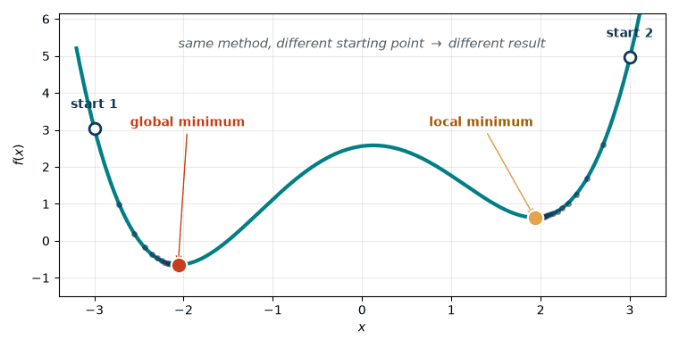

- **Local minimum:** best in a neighbourhood; **global:** best in the whole feasible set.
- A local method ends in the valley of its **starting point** — and cannot tell.
- **Convex problem** (convex $f$ over a convex set): **every local minimum is global**.
- Not guaranteed: that a minimizer **exists** ($\min_x e^x$), that it is **unique**, that the model is right.

## Optimization approaches

[figure not shown]

- *Closed form* — a formula, no iterations.
- *Gradient-based* — the derivative says where to go.
- *Linear programming* — linear $f$ and constraints; fast solvers.
- *Quadratic programming* — quadratic $f$, linear constraints; fast solvers.
- *Convex* — easy, every local minimum is global.
- *Non-convex* — hard; heuristics without guarantees.
- *Discrete* — outside the diagram; usually NP-hard.

The first two name a **method**, the rest a **property of the problem** — and the problem picks the method.

## Optimization approaches: examples

Where each class shows up in this course:

- *Closed form:* ridge regression (a matrix inverse), the sample mean and variance, PCA (eigenvectors).
- *Gradient-based:* logistic regression, neural networks.
- *Linear programming:* L₁ regression (least absolute deviations).
- *Quadratic programming:* soft-margin SVM.
- *Convex:* lasso regression, logistic regression.
- *Non-convex:* deep neural networks, k-means clustering, tuning hyperparameters (a black box, like the Gin & Tonic).
- *Discrete optimization:* feature selection.

## Training a model is optimization

[figure not shown]

- **Variables** = the parameters $\mathbf w$, not the data: a line has 2, a small network $10^6$, an LLM $10^{11}$.
- **Objective** = the loss averaged over the training set.
- Usually **no constraints** — plain gradient descent is enough.
- No formula for $\mathbf w^\star$ — but the loss and its gradient at a point are all descent needs.
- From the seventh lecture on, every network is trained by this loop.
- Even k-means is this: an objective, a bad landscape, a heuristic.

## Recap Quiz (1/2)

- **Classical programming vs. ML:** what are the inputs and outputs in each paradigm?
- **AI vs. ML vs. DL:** which is the umbrella term and how do ML and DL differ?
- **Narrow AI vs. AGI:** which one is everything in this course, and what would the other one be able to do?
- **Branches:** give one task typical for *supervised*, *unsupervised*, *reinforcement* and *self-supervised* learning.
- **Regression vs. classification:** what is predicted in each case?
- **Optimization tasks:** define an everyday task and an image or signal processing task as an optimization problem — name the variables, the objective and the constraints.
- **Minimum vs. minimizer:** which of the two is a number and which one is a point?

## Recap Quiz (2/2)

- **Feasible set:** when is a constraint *active* at the optimum, and what does that tell us?
- **Convexity:** name one property of convex functions/sets that simplifies optimization — and one thing convexity does *not* guarantee.
- **Gradient & GD:** define $\nabla f(\mathbf x)$ — scalar or vector, how many components? — and write one update step.
- **GD:** what happens when the learning rate is too large, and what sets the limit?
- **The three warm-up questions:** $x^\star=-5/6$ (and $f''=6>0$); $(1\cdot1+2\cdot(-1),\ 3\cdot1+4\cdot(-1))=(-1,-1)$; $(1+2+\dots+6)/6=3.5$.

## Appendix 1 · Mathematical background

> The notation, linear algebra, derivatives and probability that the rest of the course takes for granted. Not presented in the lecture: a reference to come back to whenever a later lecture uses one of them.

## Notation used in the course

| symbol | meaning | example in the course |
| --- | --- | --- |
| $x$, $\mathbf x$, $X$ | scalar, column vector, matrix | $y$ a label, $\mathbf x$ one sample, $X$ the whole dataset |
| $x_j$, $X_{ij}$ | $j$-th component; entry in row $i$, column $j$ | $X_{ij}$ = feature $j$ of sample $i$ |
| $\in$, $\mathbb R^d$, $\mathbb R^{n\times d}$ | is an element of; the set of real vectors of length $d$; of real $n\times d$ matrices | weights $\mathbf w\in\mathbb R^d$; data $X\in\mathbb R^{n\times d}$: $n$ samples, $d$ features |
| $\mathbf x^\top$, $X^{-1}$ | transpose, inverse | $\mathbf x_i^\top$ = row $i$ of $X$, the $i$-th sample |
| $\mathbf a^\top\mathbf b$ | dot product $\sum_i a_ib_i$ | a linear model $\mathbf w^\top\mathbf x+b$ |
| $\lVert\mathbf x\rVert_p$ | $p$-norm, the length of a vector | the distance $\lVert\mathbf a-\mathbf b\rVert_2$ in k-NN |
| $y$, $\hat y$ | true value, prediction | the error $y-\hat y$ |
| $\sum_{i=1}^n$, $\prod_{i=1}^n$ | sum, product over $i=1,\dots,n$ | the loss $\frac1n\sum_i(y_i-\hat y_i)^2$ |
| $\min_{\mathbf w} f$, $\arg\min_{\mathbf w} f$ | the smallest value of $f$; the point where it is attained | the lowest loss; the trained weights $\mathbf w^\star$ |
| $\nabla f$, $\partial f/\partial w_j$ | gradient (the vector of partial derivatives), partial derivative | a descent step $\mathbf w\leftarrow\mathbf w-\eta\nabla f$ |
| $P(A)$, $p(x)$ | probability of an event, probability density | $P(\text{spam})=0.3$ |
| $P(A\mid B)$ | probability of $A$ given $B$ | a classifier output $P(\text{class}\mid\mathbf x)$ |
| $\mathbb E[X]$, $\mathrm{Var}(X)$ | expectation, variance | one roll of a die: $3.5$ and $2.92$ |
| $\mathcal N(\mu,\sigma^2)$ | normal distribution, mean $\mu$, variance $\sigma^2$ | measurement noise in regression |
| $X$; $A$, $B$ in probability | a random variable; events — not matrices | $\mathbb E[X]$, $P(A\mid B)$ |

## Distances and vector norms

[figure not shown]

Unit balls

[figure not shown]

$\|\mathbf x\|_2=\sqrt{\sum_i x_i^2}$ $\|\mathbf x\|_1=\sum_i|x_i|$

$\|\mathbf x\|_\infty=\max_i|x_i|$ $\|\mathbf x\|_p=\bigl(\sum_i|x_i|^p\bigr)^{1/p}$

For a distance, let $\mathbf x=\mathbf a-\mathbf b$ be the difference vector.

Example: $\mathbf a=(1,1)$, $\mathbf b=(2,3)$, so $\mathbf x=(-1,-2)$: $\|\mathbf x\|_2=\sqrt5\approx2.24$, $\|\mathbf x\|_1=3$, $\|\mathbf x\|_\infty=2$.

[code example](https://github.com/tomasvicar/MLR-public/blob/master/lectures/L1/code/distances.py)

## Dot product, projection and cosine

[figure not shown]

$$\mathbf a^\top\mathbf b=\sum_i a_ib_i=\lVert\mathbf a\rVert_2\,\lVert\mathbf b\rVert_2\cos\theta$$

- **Projection** onto a unit vector $\mathbf u$: the length $\mathbf a^\top\mathbf u$.
- **Cosine similarity** $\cos\theta$: $1$ same direction, $0$ perpendicular, $-1$ opposite. The cosine distance is $1-\cos\theta$.
- **Example:** $\mathbf a=(3,1)$, $\mathbf b=(2,4)$: $\mathbf a^\top\mathbf b=10$, $\cos\theta=\frac{10}{\sqrt{10}\,\sqrt{20}}=0.707$, $\theta=45^\circ$; projection length $10/\sqrt{20}=2.24$.

*In ML:* a linear model $\mathbf w^\top\mathbf x+b$ (fifth lecture), PCA projections (third), attention scores (eleventh).

## Matrix product and shapes

[figure not shown]

- $(AB)_{ij}=\sum_k A_{ik}B_{kj}$ — row $i$ of $A$ times column $j$ of $B$.
- **Shapes:** $(n\times d)(d\times k)=(n\times k)$; the inner sizes must agree.
- $AB\neq BA$ in general; $(AB)^\top=B^\top A^\top$.
- **Inverse** $A^{-1}A=I$, only for a square $A$ with $\det A\neq0$: $\begin{pmatrix}a&b\\c&d\end{pmatrix}^{-1}=\frac{1}{ad-bc}\begin{pmatrix}d&-b\\-c&a\end{pmatrix}$.
- In code solve $A\mathbf x=\mathbf b$ with `np.linalg.solve`, do not invert.

*In ML:* a layer $W\mathbf x$ with $W\in\mathbb R^{m\times d}$ turns $d$ inputs into $m$ outputs (seventh lecture); least squares $\mathbf w=(X^\top X)^{-1}X^\top\mathbf y$ (fifth).

## Linear and affine functions

[figure not shown]

- **Linear:** $f(\mathbf x_1+\mathbf x_2)=f(\mathbf x_1)+f(\mathbf x_2)$ and $f(a\mathbf x)=a\,f(\mathbf x)$.
- Every linear $f:\mathbb R^d\to\mathbb R^m$ is $f(\mathbf x)=W\mathbf x$, so $f(\mathbf 0)=\mathbf 0$.
- **Affine:** $f(\mathbf x)=W\mathbf x+\mathbf b$ — linear plus a shift. $f(x)=2x+1$: $f(1+1)=5\neq f(1)+f(1)=6$.
- Affine of affine is affine: $W_2(W_1\mathbf x+\mathbf b_1)+\mathbf b_2$.

*In ML:* a “linear” model $\mathbf w^\top\mathbf x+b$ is strictly affine; stacked layers without a nonlinear activation collapse into one affine map — hence the activations (seventh lecture).

## Eigenvectors and eigenvalues

[figure not shown]

$$A\mathbf v=\lambda\mathbf v,\qquad \mathbf v\neq\mathbf 0$$

- $A$ only **scales** an eigenvector by $\lambda$ (a negative $\lambda$ flips it), it does not turn it. Found from $\det(A-\lambda I)=0$.
- **Symmetric** $A$: real $\lambda$, and the eigenvectors can be chosen perpendicular.
- **Positive semidefinite** (symmetric $A$): $\mathbf x^\top A\mathbf x\geq0$ for every $\mathbf x$ $\iff$ all $\lambda\geq0$. Covariance and kernel matrices are.
- **Example:** $A=\begin{pmatrix}2&1\\1&2\end{pmatrix}$, $(2-\lambda)^2-1=0$: $\lambda_1=3$, $\mathbf v_1=\tfrac{1}{\sqrt2}(1,1)$; $\lambda_2=1$, $\mathbf v_2=\tfrac{1}{\sqrt2}(1,-1)$.

*In ML:* PCA takes the eigenvectors of the covariance matrix (third lecture); a kernel matrix is positive semidefinite (fifth).

## Derivatives, the gradient and the chain rule

| $f(x)$ | $f'(x)$ |
| --- | --- |
| $x^k$ | $kx^{k-1}$ |
| $e^x$ | $e^x$ |
| $\ln x$ | $1/x$ |
| $f(x)\,g(x)$ | $f'g+fg'$ |
| $f(g(x))$ | $f'(g(x))\,g'(x)$ |

**Gradient** $\nabla f(\mathbf w)=\bigl(\frac{\partial f}{\partial w_1},\dots,\frac{\partial f}{\partial w_d}\bigr)$ points uphill and has the shape of $\mathbf w$.

[figure not shown]

**Chain rule on a graph:** forward, store the values; backward, multiply the local derivatives: $\frac{\partial L}{\partial w}=\frac{\partial L}{\partial r}\,\frac{\partial r}{\partial z}\,\frac{\partial z}{\partial w}=(-2)(1)(2)=-4$.

*In ML:* gradient descent (this lecture); backpropagation is exactly this, layer by layer (seventh lecture).

## Vector derivatives you will need

| $f(\mathbf w)$ | $\nabla f(\mathbf w)$ |
| --- | --- |
| $\mathbf a^\top\mathbf w$ | $\mathbf a$ |
| $\lVert\mathbf w\rVert_2^2=\mathbf w^\top\mathbf w$ | $2\mathbf w$ |
| $\mathbf w^\top A\mathbf w$, $A$ symmetric | $2A\mathbf w$ |
| $\lVert X\mathbf w-\mathbf y\rVert_2^2$ | $2X^\top(X\mathbf w-\mathbf y)$ |

**Shape check:** $X^\top(X\mathbf w-\mathbf y)$ is $(d\times n)(n\times1)=(d\times1)$ — the shape of $\mathbf w$.

**Least squares in three lines**

$$\begin{aligned}
\nabla\lVert X\mathbf w-\mathbf y\rVert_2^2&=2X^\top(X\mathbf w-\mathbf y)=\mathbf 0\\
X^\top X\,\mathbf w&=X^\top\mathbf y\\
\mathbf w^\star&=(X^\top X)^{-1}X^\top\mathbf y
\end{aligned}$$

**Ridge:** $+\lambda\lVert\mathbf w\rVert_2^2$ adds $2\lambda\mathbf w$, so $(X^\top X+\lambda I)\,\mathbf w^\star=X^\top\mathbf y$.

*In ML:* the fifth lecture derives OLS exactly like this and uses the ridge solution $(X^\top X+\lambda I)^{-1}X^\top\mathbf y$.

## Logarithm, exponential, sigmoid and softmax

[figure not shown]

- $\ln(ab)=\ln a+\ln b$, $\ \ln a^k=k\ln a$, $\ e^{a+b}=e^a e^b$.
- $\ln\prod_i p_i=\sum_i\ln p_i$: $0.1^{400}$ is $0$ in float64, while $400\ln 0.1=-921$ is an ordinary number.
- $\ln$ is increasing, so $\arg\max_{\mathbf w} f=\arg\max_{\mathbf w}\ln f$.
- **Sigmoid** $\sigma(z)=\frac{1}{1+e^{-z}}\in(0,1)$, $\ \sigma'=\sigma(1-\sigma)$.
- **Softmax** $\mathrm{softmax}(\mathbf z)_k=\frac{e^{z_k}}{\sum_j e^{z_j}}$ — positive, sums to one.
- *In ML:* likelihoods are maximized as sums of logs; the sigmoid (fifth lecture) and the softmax (seventh) turn scores into probabilities.

## Random variables: PMF and PDF

[figure not shown]

- **Random variable** $X$: a number produced by a random experiment.
- **Discrete — PMF:** $P(X=x)\geq0$, $\ \sum_x P(X=x)=1$. A die: $1/6$ each.
- **Continuous — PDF:** $p(x)\geq0$, $\ \int p(x)\,dx=1$.
- Probability is an **area**: $P(a\leq X\leq b)=\int_a^b p(x)\,dx$. A density may exceed $1$; a single value has probability $0$.

*In ML:* a classifier outputs a PMF over the classes; a generative model learns a density to sample from.

## Joint, marginal and conditional probability

100 e-mails, counted:

|  | “free” | no “free” | total |
| --- | --- | --- | --- |
| **spam** | 20 | 10 | **30** |
| **not spam** | 5 | 65 | **70** |
| **total** | **25** | **75** | 100 |

**Independent** if $P(A,B)=P(A)\,P(B)$; here $0.20\neq0.30\cdot0.25$.

- **Joint:** $P(\text{spam},\text{free})=20/100=0.20$.
- **Marginal** — sum a row: $P(\text{spam})=\sum_b P(\text{spam},b)=0.30$.
- **Conditional** — stay in one column:
  $$P(\text{spam}\mid\text{free})=\frac{P(\text{spam},\text{free})}{P(\text{free})}=\frac{0.20}{0.25}=0.80$$
- **Product rule:** $P(A,B)=P(A\mid B)\,P(B)$.
- The order matters: $P(\text{free}\mid\text{spam})=20/30=0.67$.

*In ML:* a confusion matrix is the same kind of table of counts (second lecture).

## Bayes’ rule

$$P(A\mid B)=\frac{P(B\mid A)\,P(A)}{P(B)}$$

$$P(B)=\sum_a P(B\mid a)\,P(a)$$

- **posterior** = **likelihood** × **prior** / **evidence**.
- Turns what we can measure, $P(+\mid\text{sick})$, into what we need, $P(\text{sick}\mid+)$.
- A disease in 1 of 1000, a test 99 % sensitive and 99 % specific:
  $$P(\text{sick}\mid+)=\frac{0.99\cdot0.001}{0.99\cdot0.001+0.01\cdot0.999}=0.090$$

[figure not shown]

*In ML:* a rare class has a small prior — so even a small false-positive rate ruins the precision of the positive predictions (second lecture).

## Expectation, variance and covariance

- **Expectation** $\mathbb E[X]=\sum_x x\,P(X=x)$; a die: $3.5$.
- **Variance** $\mathrm{Var}(X)=\mathbb E\bigl[(X-\mathbb E[X])^2\bigr]$, $\ \sigma=\sqrt{\mathrm{Var}(X)}$; a die: $35/12=2.92$, $\sigma=1.71$.
- **From data:** $\bar x=\frac1n\sum_i x_i$, $\ s^2=\frac{1}{n-1}\sum_i(x_i-\bar x)^2$.
- **Covariance** $\mathrm{cov}(X,Y)=\mathbb E\bigl[(X-\mathbb E[X])(Y-\mathbb E[Y])\bigr]$, **correlation** $r=\frac{\mathrm{cov}(X,Y)}{\sigma_X\sigma_Y}\in[-1,1]$.
- **Rules:** $\mathbb E[aX+b]=a\,\mathbb E[X]+b$, $\ \mathrm{Var}(aX+b)=a^2\,\mathrm{Var}(X)$.
- **Average of $M$ independent copies:** variance $\sigma^2/M$.

[figure not shown]

*In ML:* standardization (second lecture), correlation and the covariance matrix in PCA (third), bagging averages trees to lower the variance (sixth).

## The normal distribution

[figure not shown]

$$\mathcal N(x;\mu,\sigma^2)=\frac{1}{\sqrt{2\pi\sigma^2}}\exp\Bigl(-\frac{(x-\mu)^2}{2\sigma^2}\Bigr)$$

- $\mu\pm\sigma$, $\pm2\sigma$, $\pm3\sigma$ hold $68.3\,\%$, $95.4\,\%$, $99.7\,\%$.
- An average of many independent effects is close to normal.

$$\mathcal N(\mathbf x;\boldsymbol\mu,\Sigma)=\frac{\exp\bigl(-\tfrac12(\mathbf x-\boldsymbol\mu)^\top\Sigma^{-1}(\mathbf x-\boldsymbol\mu)\bigr)}{\sqrt{(2\pi)^d\det\Sigma}}$$

- Contours are ellipses: axes along the eigenvectors of $\Sigma$, half-lengths $k\sqrt{\lambda}$ at $k$ standard deviations.
- $-\ln\mathcal N(y;\hat y,\sigma^2)=\frac{(y-\hat y)^2}{2\sigma^2}+\text{const}$: Gaussian noise $\Rightarrow$ the MSE loss.

## Entropy, cross-entropy and KL divergence

[figure not shown]

- **Entropy** $H(p)=-\sum_k p_k\log p_k$ — the uncertainty of $p$. With $\log_2$ in bits: a fair coin $1$, a $0.9/0.1$ coin $0.469$, a certain outcome $0$.
- **Cross-entropy** $H(p,q)=-\sum_k p_k\log q_k$ — the cost of describing $p$ with a model $q$.
- **KL divergence** $D_{\mathrm{KL}}(p\,\Vert\,q)=H(p,q)-H(p)\geq0$, zero only for $q=p$.
- **Classification loss:** a one-hot $p$ gives $H(p,q)=-\ln q_{\text{true}}$. The softmax $0.659$ on the true class costs $0.417$; $0.099$ costs $2.32$.
- *In ML:* mutual information (third lecture), the impurity of a tree (sixth), the cross-entropy loss (seventh).

## Appendix 1: check yourself

- **Norms:** write the formulas for $\lVert\mathbf x\rVert_2$, $\lVert\mathbf x\rVert_1$ and $\lVert\mathbf x\rVert_\infty$ (for $\mathbf x=\mathbf a-\mathbf b$).
- **Shapes:** a layer turns 3 inputs into 4 outputs — what is the shape of $W$ in $W\mathbf x$?
- **Linearity:** is $f(x)=3x+2$ linear, affine, or neither?
- **Gradient:** what is $\nabla_{\mathbf w}\lVert X\mathbf w-\mathbf y\rVert_2^2$, and what shape does it have?
- **Eigenvalues:** what are the eigenvalues and eigenvectors of $\begin{pmatrix}2&0\\0&5\end{pmatrix}$?
- **Logarithm:** why is a likelihood maximized as a sum of logs, not as a product?
- **Bayes:** a disease in 1 of 100, a test 90 % sensitive and 90 % specific — what is $P(\text{sick}\mid+)$?
- **Cross-entropy:** what is the loss when the network gives the true class a probability of 0.5?

## Appendix 2 · Recap of BPC-UIN algorithms

> Nearest neighbours, k-means and UPGMA — a refresher from the bachelor course. Not presented in the lecture: read it before the first lab, which computes distances (Appendix 1) and a nearest-neighbour decision by hand.

## Nearest Neighbor (1-NN)

**Idea**

- For $\mathbf x_\ast$ find the *closest* training point and copy its label: $\hat y(\mathbf x_\ast)=y_{(1)}$.

**Properties**

- No training phase (lazy learning).
- Sensitive to noise, scaling and outliers.
- Search is expensive for large $n$ (kd-tree).

[figure not shown]

## k-Nearest Neighbors (k-NN)

- Find the $k$ closest neighbors $\mathcal N_k(\mathbf x_\ast)$; majority vote (classification) or average (regression).
- $k$ regularizes the model (bias–variance trade-off).

[figure not shown]

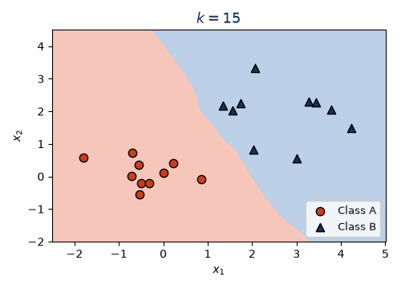

Playground on the next slide · [code example](https://github.com/tomasvicar/MLR-public/blob/master/lectures/L1/code/knn.py)

## k-NN playground

[interactive chart not shown]

**k = 1**

Metric:

Add on click: A (red circle) B (blue triangle)

**Click** on the canvas to add a point (**right-click** or **shift-click** always adds B), **drag** any point or the orange query star to move it.

The twenty points are those of the 1-NN slide; the shading is the classifier's decision. Odd k only, so the vote cannot tie.

## k-means Clustering

**Idea**

- $n$ points into $k$ clusters, each represented by its mean.
- Minimize the **inertia**:

$$J=\sum_{j=1}^{k}\ \sum_{\mathbf x_i\in C_j}\ \|\mathbf x_i-\boldsymbol\mu_j\|_2^2$$

**Algorithm (Lloyd’s)**

1. Initialize $k$ centroids (random samples).
2. Assign each $\mathbf x_i$ to the nearest centroid.
3. Move centroids to the means of their points.
4. Repeat 2–3 until nothing changes.
- Depends on initialization (restart several times); finds a local minimum.

## k-means Clustering: the algorithm step by step

[figure not shown]

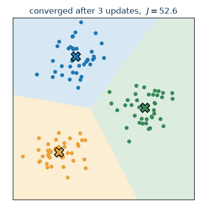

[figure not shown]

Every assignment step and every means update can only **decrease** $J$ — that is why Lloyd’s algorithm always converges (to a local minimum).

[code example](https://github.com/tomasvicar/MLR-public/blob/master/lectures/L1/code/kmeans.py)

## By hand: a k-NN vote and one k-means step

Six training points — the data of [`code/knn.py`](https://github.com/tomasvicar/MLR-public/blob/master/lectures/L1/code/knn.py): class A $(1,2)$, $(1.5,1.8)$, $(1,0.6)$; class B $(5,8)$, $(8,8)$, $(9,11)$.

**k-NN, $k=3$, new sample $(2,3)$**

| point | class | $d_2$ to $(2,3)$ |
| --- | --- | --- |
| $(1.5,1.8)$ | A | **1.30** |
| $(1,2)$ | A | **1.41** |
| $(1,0.6)$ | A | **2.60** |
| $(5,8)$ | B | 5.83 |
| $(8,8)$ | B | 7.81 |
| $(9,11)$ | B | 10.63 |

Three nearest: A, A, A $\Rightarrow$ **class A** ($k=5$: 3 : 2, still A).

**k-means, $k=2$, initial means $\boldsymbol\mu_1=(1,2)$, $\boldsymbol\mu_2=(5,8)$**

| point | $d$ to $\boldsymbol\mu_1$ | $d$ to $\boldsymbol\mu_2$ | cluster |
| --- | --- | --- | --- |
| $(1,2)$ | 0.00 | 7.21 | 1 |
| $(1.5,1.8)$ | 0.54 | 7.12 | 1 |
| $(5,8)$ | 7.21 | 0.00 | 2 |
| $(8,8)$ | 9.22 | 3.00 | 2 |
| $(1,0.6)$ | 1.40 | 8.41 | 1 |
| $(9,11)$ | 12.04 | 5.00 | 2 |

Assignment: $J=36.25$. Update: $\boldsymbol\mu_1=(1.17,\,1.47)$, $\boldsymbol\mu_2=(7.33,\,9.00)$, $J=15.98$. Next assignment unchanged — **converged**.

## UPGMA

*Unweighted Pair Group Method With Arithmetic Mean*

**Idea**

- Hierarchical: repeatedly merge the two closest clusters.
- Cluster distance = average of all pairwise distances.
- Result: a tree (dendrogram).

**Algorithm**

1. Every sample is a cluster.
2. Merge the closest pair.
3. Update the distance matrix (averages).
4. Repeat until one cluster remains.

**Cluster distance definition**

Merging $C_i$ and $C_j$ ($|C_i|$ = size): the distance to another cluster $C_k$ becomes

$$d(C_{i\cup j},C_k)=\frac{|C_i|\,d(C_i,C_k)+|C_j|\,d(C_j,C_k)}{|C_i|+|C_j|}$$

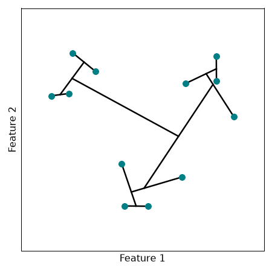

## UPGMA: practical construction

[figure not shown]

[code example](https://github.com/tomasvicar/MLR-public/blob/master/lectures/L1/code/upgma.py)

## Appendix 2: check yourself

- **1-NN vs. k-NN:** how does the prediction differ and what is $k$ trading off?
- **k-means:** what objective does it minimize and what makes it sensitive?
- **UPGMA:** how is the distance to a newly merged cluster computed?